# `GardenBench`: A lightweight, daily evaluation of LLM capabilities

Authors

Benedict Cummins-Mburu

Mariana Garcia Mejia

Oscar Heath

Sabrina Kreyzerman

Ellie Murray

Arusan Surendiran

Rohan Alexander

Published

August 17, 2026

Abstract

We introduce `GardenBench`, a benchmark with 11 test suites that evaluate the capabilities of Large Language Models (LLMs) across a range of tasks. By systematically prompting LLMs with various lightweight queries, we document day-to-day changes in model performance, including run costs and times, that other benchmarks miss. This allows us to compare the accuracy and features of responses across model providers and versions. We account for daily variations in model accuracy, capturing both model progress and degradation. Our benchmarking pipeline is reliable and scalable as we evaluate accuracy as a binary variable (correct or incorrect) using exact-match strings on deterministic ground truths. We base our evaluation on general-use tasks and make our results publicly accessible via a live dashboard, diversifying existing approaches to LLM testing. Our main contribution is an innovative, lightweight, and inexpensive benchmark, designed to be consumer-facing and for everyday tasks.

**Keywords:** Artificial intelligence; AI; Benchmarks; Large Language Models; LLMs

# 1 Introduction

Progress depends on the instruments we use to measure it. Traditionally, machine learning (ML) models were trained for and tested on task-specific functions. For example, models were deliberately trained to perform visual recognition and object classification in the ImageNet challenge (Russakovsky et al. 2015) and movie recommendation enhancement in the Netflix Prize contest (Bell et al. 2010). But in 2020, the release of GPT-3 (Brown et al. 2020), one of the first publicly accessible and general-use large transformer models, shifted the trajectory of LLM training and testing. Brown et al. (2020) found that sufficiently large transformer models that were trained only on next-token prediction could perform competitively with fine-tuned state-of-the-art (SOTA) models on tasks that were not in their training data. This property of LLMs drove their rapid spread as general-purpose tools. Today, LLMs are used as search engines, office assistants, and personal tutors, among other general use cases. LLMs are referred to as foundation models (Bommasani et al. 2022; Liang et al. 2023), used to perform a broad range of tasks, including text summarization, translation, coding, image generation, and answering practical questions. LLMs are also often able to process multimodal inputs, such as image files and PDF documents.

Though LLM use has broadened, the evaluation and documentation of LLM performance remains scientifically oriented and domain-specific. In addition, many model benchmarks are computationally expensive and take long to run (Polo et al. 2024). As a result, model providers assess overall performance by evaluating newly released models once upon their release. Model capabilities across specialized tasks are reported in model cards, for example, GPT-5.5 (OpenAI 2026a), Gemini 3.5 Flash (Google DeepMind 2026), and Claude Opus 5 (Anthropic 2026b).

We identify two shortcomings in this practice. First, model cards are published by model developers, allowing them to selectively showcase model abilities and exclude failures. The same applies for many benchmarks, with model developers either choosing which benchmark performances to publish or constructing their own (for example, Anthropic’s Anthropic (2026a) to evaluate Claude Fable 5). Second, early one-time evaluation of models does not capture changes in performance and reliability over time, whether model progress or model drift. Model drift refers to the performance degradation of LLMs as data and language patterns, and without running benchmarks repeatedly over time, we are unable to quantify or record this phenomenon properly. Hence the need for cost-effective, lightweight benchmarks that we can run everyday.

In this paper, we respond to calls for the adoption of publicly accessible benchmarks (for example, Guha et al. 2026), as well as benchmarks that evaluate model performance more frequently and on diverse and general use cases (for example, Hodak et al. 2024; Liang et al. 2023). This kind of wide-ranging evaluation is intended to align LLM benchmarks with broader LLM use.

We expand on existing benchmarks in a number of ways. Primarily, our tests comprise a combination of innovative and practical tasks. Whereas many benchmarks focus on specific skills, such as coding (SWE-bench (Jimenez et al. (2024)); Terminal-Bench (Merrill et al. (2026))), summarization (SummEval (Fabbri et al. (2021)); UserSumBench (Wang et al. (2024))) and translation (LingualX64 (Song et al. (2025)); MMLU-ProX (Xuan et al. (2025))) , our tests measure model capability across tasks that require multiple skills, such as image recognition, logical and arithmetic reasoning, and information extraction. Second, the complete benchmark costs less than $50 USD in total to run, allowing for personal use by interested parties. Third, our tests run every day, with the results systematically published to a publicly accessible live dashboard (available at https://gardenbench.ai/).

The remainder of this paper is structured as follows. Section 2 provides a contextual background, where we identify and address shortcomings in existing benchmarks. Section 3 details our experimental approach, including the construction of our dataset and the models that are evaluated. Section 4 covers our findings regarding model performance, evaluated against metrics such as run cost and time. Section 5 discusses key takeaways, implications, weaknesses, and future directions.

# 2 Background

In machine learning (ML), standard benchmarks are measurement instruments consisting of questions and answers, and a metric to evaluate model performance across different tasks (Raji et al. 2021). Traditionally, benchmarks are designed to test specific capabilities, such as summarizing documents (SummEval (Fabbri et al. (2021)); UserSumBench (Wang et al. (2024))) and coding (SWE-bench (Jimenez et al. (2024)); Terminal-Bench (Merrill et al. (2026))) or tailored to different domains of knowledge, such as math (MathBench (Liu et al. (2024))), biology (LABBench2 (Laurent et al. (2026))) or general knowledge (MMLU (Hendrycks et al. (2021)); HLE (Phan et al. (2026)); GPQA (Rein et al. (2023))). They are also intended to compare models through objective metrics (Raji et al. 2021), allowing for the quantitative tracking of LLM progress, the ranking of models by performance, and the identification of the most promising technologies to guide research efforts and general usage (Zhu et al. 2025).

## 2.1 Transparency and reliability concerns in domain-specific benchmarks

Concerns about transparency in existing LLM benchmarks are well documented and characterized by several key shortcomings. Namely, scholars warn that LLM evaluation occurs predominantly as a closed-door practice, where model providers selectively publish their own evaluations (Cheng et al. 2025; Baack et al. 2026), benchmark results target niche professional communities (Koch et al. 2021), and evaluation metrics are not useful to the broad scope of LLM users (Raji et al. 2021; Eriksson et al. 2025). For example, Guha et al. (2026) calls for more publicly accessible and transparent LLM benchmarks, arguing that the benchmarking process functions like a spectrum: one on extrema, organizers either publish all the code and data, and on the other, they only provide broad descriptions of findings. Intermediate approaches in the middle of the spectrum, which include selectively publishing only a subset of the results, are affecting AI transparency, and are predominant in current benchmarking practices.

Conventionally, newly released ML models are evaluated on a set of highly specialized benchmarks, with the results used to demonstrate the model’s strengths. This practice enables providers to publish benchmarks on which their models perform well, while less successful performances remain undisclosed (Cheng et al. 2025; Baack et al. 2026). For instance, party researchers have reported lower scores for models on certain benchmarks compared to scores reported by model creators. Akter et al. (2023) reported a 5-shot MMLU score of 65.22%, whereas the Gemini paper reported a 5-shot MMLU score of 71.8% (Gemini Team 2023). Efforts to tackle this problem include Bommasani et al. (2023), which introduced the Foundation Model Transparency Index (FMTI) in 2023 to expose and improve the disclosure practices of frontier model developers, such as Anthropic, Google, and OpenAI (for the most recent version, see Wan et al. (2025)). The FMTI is an effort to advance the transparency of model developers across their computational methods, labor practices, the real-world implications of LLMs, among other metrics.

Aside from transparency concerns, other scholars question the trustworthiness of current LLM benchmarking practices. Cheng et al. (2025) highlights that issues like data contamination—which happens when the test data has been included in the model’s training data, leading to the model performing exceptionally well on these leaked test data (Dong et al. (2024))—can lead to biased model evaluations. This makes it difficult to distinguish between exaggerated claims about model performance and genuine progress. Eriksson et al. (2025)’s comprehensive literature review of benchmarking practices highlighted other important vulnerabilities of current approaches, including the fact that most benchmarks are ill-suited for practical use in the real world and display a serious lack of documentation. They have also been critiqued for being too narrow and primarily-text based, ignoring capabilities of models in other modalities such as imagery and sound.

Moreover, it has become increasingly difficult for the general public to interpret benchmark results as they are often highly technical and domain-specific. Guha et al. (2026) argues that the capacity to understand benchmarking information largely depends on the technical sophistication of individuals in a specific community, making communities who are deeply experienced in using AI more likely to benefit from benchmarking reports and studies compared to those who are not. There is also an important discrepancy between LLM potential and real LLM applications, likely due to a misalignment between capabilities demonstrated by model developers and real-world applications (Narayanan 2026; Eriksson et al. 2025; Hutchinson et al. 2022; Cheng et al. 2025).

More broadly, AI companies test their new models in a set of widely used benchmarks. When Anthropic released Claude Fable 5 in July 2026, the company highlighted results from `SWE-bench` (Jimenez et al. 2024), `Terminal-Bench` (Merrill et al. 2026), `ExploitBench` (Lee and Brumley 2026), and `BioMysteryBench` (Anthropic 2026a). `BioMysteryBench` in particular was constructed by Anthropic to test its own model. Respectively, these benchmarks test agentic coding, command-line coding, cybersecurity, and biology. GPT-5.6 Sol was also evaluated on similar measures (see Reuel et al. 2024; Li and Ho 2026; Lee and Brumley 2026; Wang et al. 2026). While these insights are important for model development, or medical applications, these metrics may not be useful to LLM users outside professional communities, who use LLMs for ordinary, everyday tasks. It is very likely that most casual LLM users have never heard of these benchmark names before.

## 2.2 The limitations of expensive model testing

The expensive cost of many LLM benchmarks is a second vulnerability of existing approaches. Gundlach et al. (2026) found that the cost of benchmarking frontier models is increasing by 3 to 18 times yearly, as models continue to grow in size and require more internal thinking before outputting responses. As a result, running the same benchmarks is becoming more expensive each time as new models come out, naturally because these models are more expensive to run. It is also an issue that some benchmarks are themselves expensive to run. Some examples of this include, Kapoor et al. (2025)’s “Holistic Agentic Leaderboard” which reported costing $40,000 USD to run once across nine models and nine benchmarks, and GAIA “A Benchmark for General AI Assistants” (Mialon et al. 2023), which reported costs of over $2,829 USD on frontier models for a single run (Ndzomga 2026).

Aside from running the benchmark once to calculate model performance, it is also of interest to average performance across repeated runs of the same benchmark, to get a sense of model reliability, a critical feature of LLM evaluation. Multiple studies examining the consistency and reproducibility of LLM outputs have found that model accuracy varies over time and from prompt to prompt. For example, Cui and Alexander (2026) examined the ability of LLMs to produce the same response to the same prompt ten-out-of-ten times and found that model output differs even between executions with the same settings (prompting strategy and temperature settings). Additionally, Mehta (2025) found that agent performance can drop from 60% (single run) to 25% (8-run consistency), suggesting that benchmarks should ideally be run more than once to get a full picture of model performance. Other studies investigating model reliability include Rabanser et al. (2026); Pinhanez et al. (2025); Ahn and Yin (2025); Patwardhan et al. (2025).

The increase in cost and need for frequent evaluation are clearly at odds with one another. The cost of evaluating LLMs constitutes a new bottle neck, and in practice results in infrequent testing of LLMs. Researchers are calling for attention to the computational resources needed to evaluate LLM performance, taking realistic economic constraints into account when assessing the feasibility of running these benchmarks to capture reliability and other characteristics of interest (Gundlach et al. 2026).

Model cards - reports of newly released models proposed by Mitchell et al. (2019) - show results from tests performed only once, treated as a one-time evaluation of the model. (Example model cards from the models included in our study are GPT-5.5 (OpenAI 2026a), Gemini 3.5 Flash (Google DeepMind 2026), and Claude Opus 5 (Anthropic 2026b)). While model cards comprehensively summarize model performance across various capabilities, they do not account for model, or temporal drift—the performance degradation of LLMs as data and language patterns, as well as domain-specific knowledge, change over time (Khairnar 2025). As a result, model cards quickly become outdated as new model versions are released and as time passes, because disclosed and structured testing is halted. For example, Chen et al. (2024) documented how the performance of GPT-3.5 and GPT 4 in math problems, degraded in a matter of months. They found that GPT-4’s accuracy in identifying prime numbers dropped from 84% in March 2023 to 51% by June 2023, suggesting that model performance is non-static, and should be monitored over time for potential divergence. Adding to infrequent testing, model cards are published by model developers, reinforcing doubts about transparency and impartiality.

## 2.3 Related work

Public dashboards that report LLM capabilities across a variety of skills, models and benchmarks are already available. Some examples include Arena, formerly ChatBot Arena (Chiang et al. 2024), and EpochAI (Epoch AI 2026). We follow these dashboards in adopting independent and public-facing testing of LLMs, while addressing areas for improvement. First, Arena is a crowd-sourced approach that allows public users to rank their preferred model responses on a variety of tasks, without disclosing the model that produced the response. This helps reduce bias in responses, enables frequent evaluation of new models, and allows for the input of those directly using LLMs in their daily lives. However, it relies on the participation of the public, meaning the dashboard does not update if people are not using it. Additionally, Arena does not allow for quantitative comparisons between models. Similarly, EpochAI primarily examines model accuracy against its release date without accounting for potential trade-offs when seeking high performance, such as the time and cost of testing. Further, models are not tested beyond their initial release.

There are also independent web dashboards for commonly used benchmarks, such as the SWE-bench Leaderboard [https://www.swebench.com/] which evaluates the coding benchmark SWE-bench (Jimenez et al. 2024) on frontier models and makes results accessible to the public. Another example is the Artificial Analysis dashboard, which [https://artificialanalysis.ai/evaluations/humanitys-last-exam] displays performance on the HLE “Humanity’s Last Exam” benchmark, which comprises domain-specific questions developed by field experts (Phan et al. 2026). Even though presenting model performance on common benchmarks through live dashboards or websites makes this information more accessible to the broader public, these websites are not updated as frequently, possibly due to the compounding costs of running these benchmarks frequently and as more expensive models are released.

`GardenBench` was designed with consideration of both the shortcomings and advantages of existing approaches to LLM benchmarking: reliability, costs and accessibility to the general public. We propose a diversified benchmark that includes a wide variety of everyday tasks that reflect general use cases, many of which can be accomplished by humans. We test LLM capabilities ranging from contextual knowledge to image recognition in a way that is lightweight, cheap, and fast to run such that we can gauge model performance and reliability by running the benchmark multiple times and overtime. In doing so, we contribute to academic efforts in the movement toward publicly accessible and general-use benchmarks.

# 3 Data and methods

## 3.1 Developing testing suites

In constructing our testing methodology, we follow extensive literature on prompt engineering (for example, Ggaliwango et al. 2024; Sahoo et al. 2025) and the instruction-following capabilities of LLMs (for example, Zhou et al. 2023; Wu et al. 2024). These studies find that developing specific and intentional query structures, combined with length and formatting constraints (for instance, capitalization and punctuation), is critical in maximizing the utility and efficacy of LLMs.

Our benchmark consists of 107 individual tests organized into 11 distinct testing suites. A brief overview of each suite and their associated tasks is available in Table 1. We distinguish between image- and text-based suites because some of the models we evaluated, such as DeepSeek, are not natively capable of image processing. Similarly, sound-based tasks were initially considered (for example, recognizing songs from audio recordings), but ultimately discarded as few models in 2026 natively support audio file processing[^1]. As we evaluate model capabilities without tool use, audio-based tasks were not feasible. For our final collection of tasks, all correct answers could be found within the image or text in the prompt, meaning web searching was not required. Our objective in this approach was to evaluate raw LLM capabilities without the support of external resources.

Tests in the same suite either evaluate LLMs on different versions of the same task or multiple closely related but distinct tasks. For instance, the *Birds* suite consists of 10 instances of the same task: “Identify the species of the bird shown in this image.” Conversely, the *Books* suite contains single instances of 9 different tasks, all of which ask the LLM to extract different information from a photograph of a bookshelf (for example, the title and author of one of the books).

Our collection of suites reflects diverse everyday tasks that test a broad range of LLM capabilities while being effectively cost-efficient to run. The *Ciphers*, *Puzzles*, *Clothing*, *Transit*, and *Colours* suites test the model’s ability to reason across different domains and based on different media input types. The *Countries* and *Birds* suites test base LLM knowledge, when access to tools such as web searching was restricted. The *Haystack* and *Books* suites test information retrieval. We also included a self-check, where the LLM was prompted to return its own model slug, a string used to identify a specific model.

We only considered tasks which could be evaluated on a binary pass or fail. This was done to make the results of `GardenBench` easily interpretable. In addition, models were only given a single chance to respond, and example responses were not provided in the prompts. This zero-shot prompting style is intended to emulate how a human with a quick question would interact with an LLM. Model responses were evaluated using exact string matching between the model output and the test’s ground truth. To support reliability and scalability, the exact same bytes were sent to each API. Moreover, prompts each demanded a specific response structure from the LLM with no pleasantries, throat clearing, or other excess communication. Therefore, our approach simplifies evaluation, making results easily conceivable to broad LLM users without sacrificing depth of analysis. An example prompt from the *Ciphers* suite is shown in Figure 1. A more complete description of our suites is available in Appendix 7.

Table 1: Set of suites considered in our study with their reference names, number of tests they contain, and a one-sentence task description.

| Suite Name | Number of Tests | Input Type | Task Description |
| --- | --- | --- | --- |
| Birds | 10 | Image | Identify the species of bird from its image |
| Books | 9 | Image | Identify information from an image of a bookshelf. |
| Clothes | 10 | Image | Identify information from an image of a wardrobe. |
| Colours | 12 | Image | Identify paint types and colour mixtures from an image of a paint palette. |
| Countries | 11 | Image | Identify the country from an image of its silhouette. |
| Graphs | 10 | Image | Identify the equation of the derivative from a graph of a simple function. |
| Transit | 10 | Image | Identify information from a map of a transit system. |
| Ciphers | 10 | Text | Decode a word transformed with a cipher. |
| Haystack | 8 | Text | Identify a target string within a large corpus of text. |
| Puzzles | 12 | Text | Solve logical puzzles. |
| Self-Check | 5 | Text | Answer questions about self. |

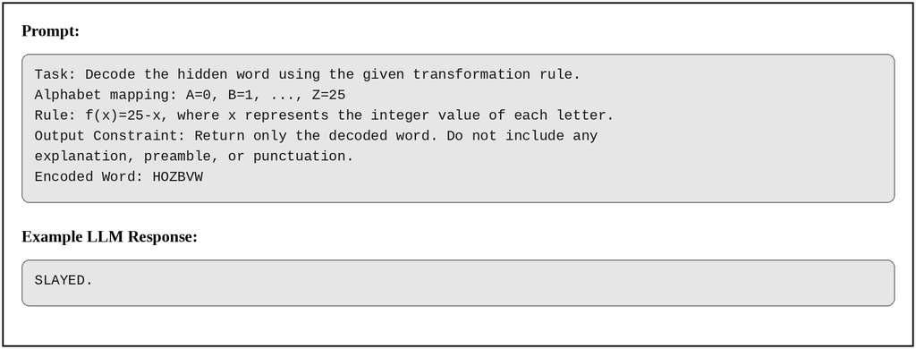

## 3.2 Models

The set of models presented in this paper will change as providers release new model versions and discontinue older ones. As a result, `GardenBench` provides a permanent timeline of a model’s performance on everyday tasks. This means that changes in performance, for instance, model drift, will be captured in the timeline of our benchmark.

Table 2: Set of models evaluated in our study, organized by their providers, with their names, native image support capability, and frequency of evaluation.

[output not shown]

## 3.3 Evaluation Metrics

Beyond simply measuring performance, we analyze model accuracy as a function of several relevant variables. First, we analyze the relationship between average dollar cost per test and accuracy. This serves two purposes. For many people deciding which model to use for non-frontier application, cost is an important constraint, and is not often accounted for in existing benchmarks. Additionally, plotting average cost per test gives a more transparent cost comparison between models than price-per-token, which is what providers often use to represent cost. This metric only allows comparison under the assumption that all models output roughly the same number of tokens to solve a given problem. However, due to chain-of-thought reasoning, we find that some models output significantly more tokens than others to solve the same problem. Therefore, we analyze the relationship between accuracy and output token use in order to measure token efficiency. Finally, we measure average accuracy as a function of wall-clock time elapsed to solve tests. Time is another metric that can inform decisions of which model to use for real-world applications. LLMs that take minutes rather than seconds to respond may not usefully act as search engines or office assistants.

## 3.4 Evaluation schedule

Our primary product is a set of visualizations of daily `GardenBench` evaluations, which are updated regularly and made publicly available at https://gardenbench.ai/. This website contains the same visualizations presented in our Results section, along with additional visualizations, such as breakdowns across models and their specific capabilities tested by the suites, compared to just looking at aggregated accuracy across all suites. To preserve the integrity of our experiment while running `GardenBench` daily, we do not publicize our underlying dataset. This decision was informed by concerns about dataset contamination, where model training data and evaluation data may intersect, enabling LLMs to memorize responses, thus causing performance to be overstated (Xu et al. 2024; Fu et al. 2025; Li et al. 2024). There is also less literature on how to navigate the risk of data contamination for emerging dynamic benchmarks (Chen et al. 2025), such as ours.

[figure not shown]

Figure 2: Research workflow.

# 4 Results

## 4.1 Aggregate performance

The average accuracy achieved by each model across all 11 test suites considered in this study is presented in Figure 3. Results shown in this, and subsequent, visualizations were averaged over the period from July 20 to July 28 2026. Replicate figures are presented on the website. Further, and as mentioned in Section 3, some of our chosen models (Deepseek V4 Flash, Deepseek V4 Pro, and Command R+) were only evaluated on text-based suites (see Table 1), which only represent 4 out of the 11 total suites devised. Due to this, these models’ performance will largely be discussed separately to the others.

The highest performing model evaluated on the full benchmark was GPT-5.6 Sol, followed closely by GPT-5.5, achieving an average per-suite accuracy of 72 percent and 71 percent respectively. Performance decreased steadily across the remaining models, with a notable drop below 0.5 average accuracy from Kimi K2 to Claude Opus 4.8. Both Deepseek V4 Flash and V4 Pro models performed similarly on the text-based suites, and achieved average accuracies much higher than Command R+ (92 and 88 percent compared to 22 percent). When other models’ accuracy was evaluated on only their text-based performance, both Deepseek models still placed among the strongest performers, comparable to GPT-5.5 and GPT-5.6 Sol, which achieved average text-based accuracies of 93 percent and 90 percent, respectively.

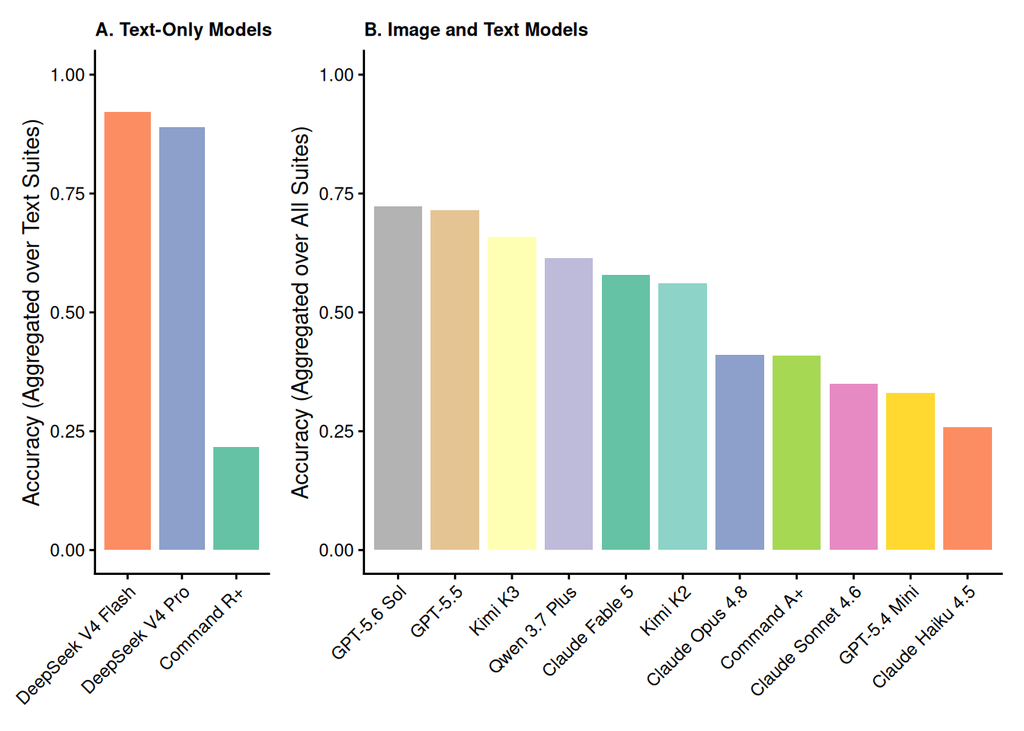

Figure 3: Performance by model, separated into text-only models (A) and models that can handle image input (B).

## 4.2 Overall accuracy per suite

Figure 5 displays the performance of a few select models on individual suites. We observe that some models perform relatively better or worse on certain suites (or groups of suites), meaning that overall aggregated accuracy metrics are not necessarily representative of a model’s specific capacities. For example, Claude Fable 5 underperformed significantly on text-based suites relative to other frontier models, otherwise performing similarly on image-based suites. Model performance on specific suites is discussed further Appendix 8.

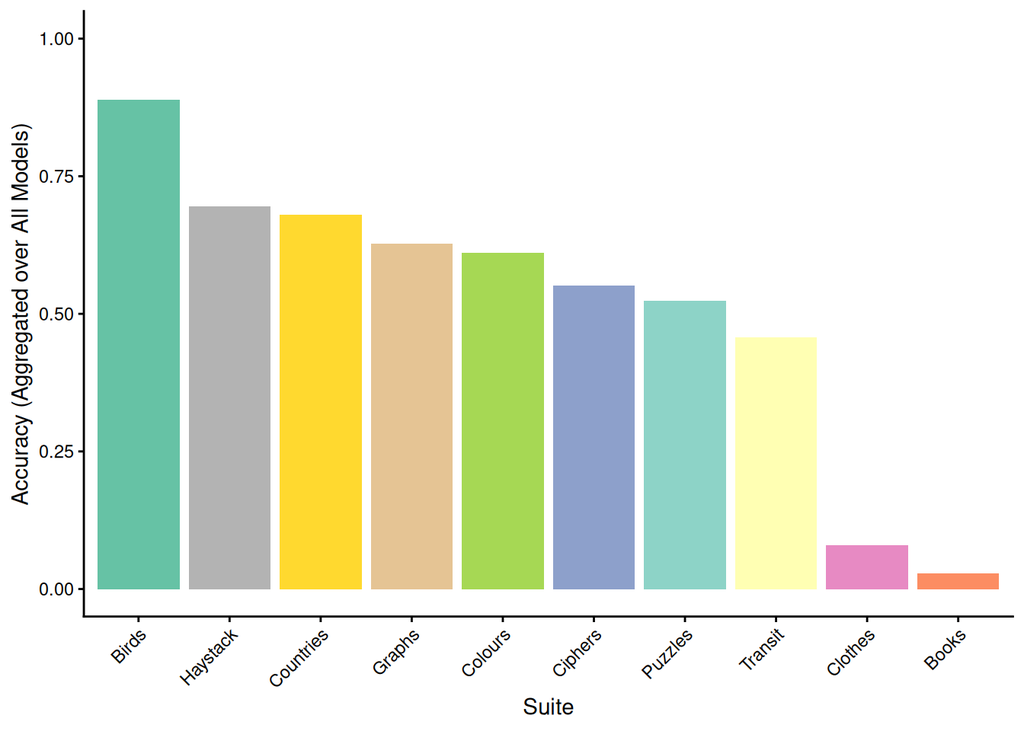

Figure 4: Performance by suite, averaged across all models and dates. Note that image-based suites were evaluated on a smaller set of models, as DeepSeek V4 Flash, DeepSeek V4 Pro, and Command R+ could not process image inputs.

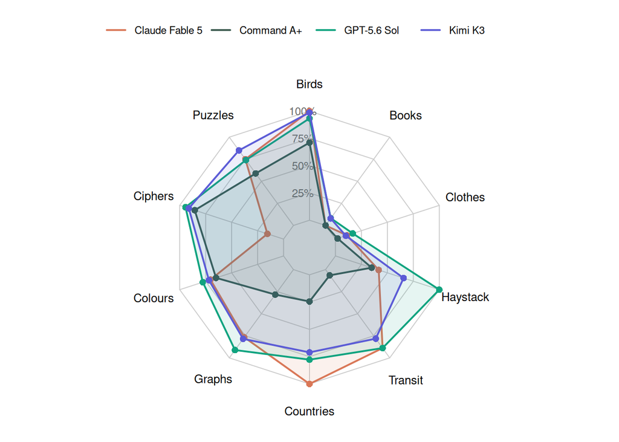

Figure 5: Radar plot displaying the performance of Claude Fable 5, Command A+, GPT-5.6 Sol, and Kimi K3 across each suite considered. Models are colour-coded according to their model providers.

## 4.3 Overall accuracy by run time and cost per model

The complete benchmark costs approximately $50 USD and takes up to one hour per day to run. We plot the average per-suite accuracy of each model against its average cost and time-to-run in Figure 6 and Figure 7 respectively. Deepseek V4 Flash, Pro, and Command R+ are not shown in these plots since they were evaluated on a much smaller subset of tests.

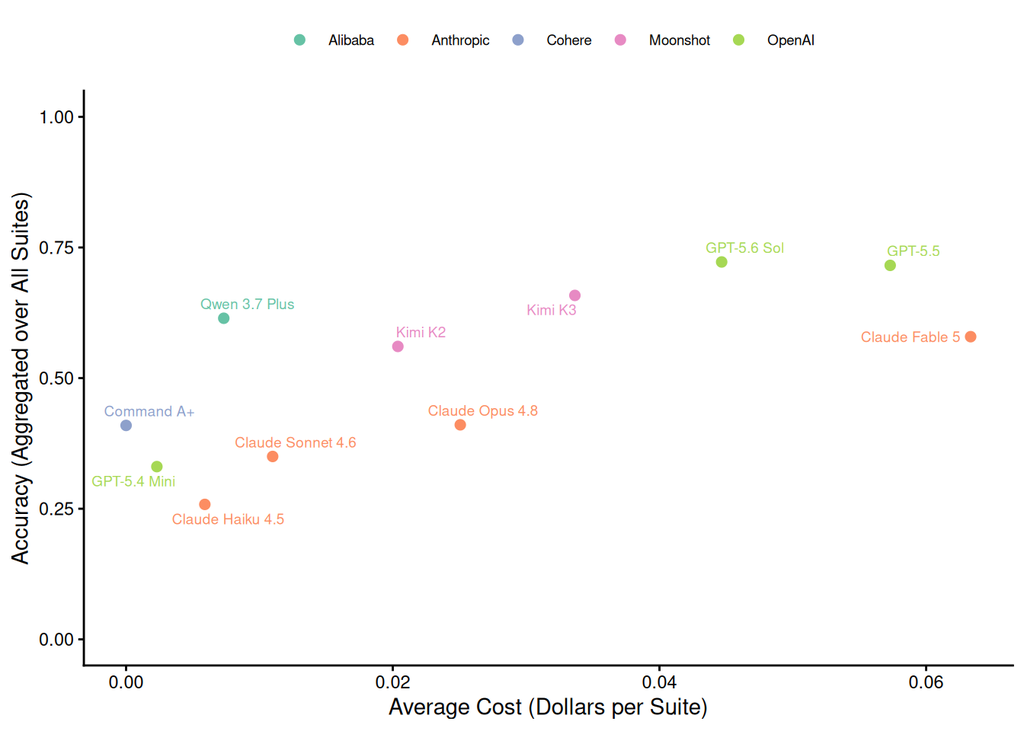

Figure 6: Relationship between accuracy and cost averaged over all suites for every model in our study, represented as points. Points are colour-coded according to their model providers. DeepSeek V4 Flash, DeepSeek V4 Pro, and Command R+ were omitted from this plot, as they were only evaluated on text-based suites.

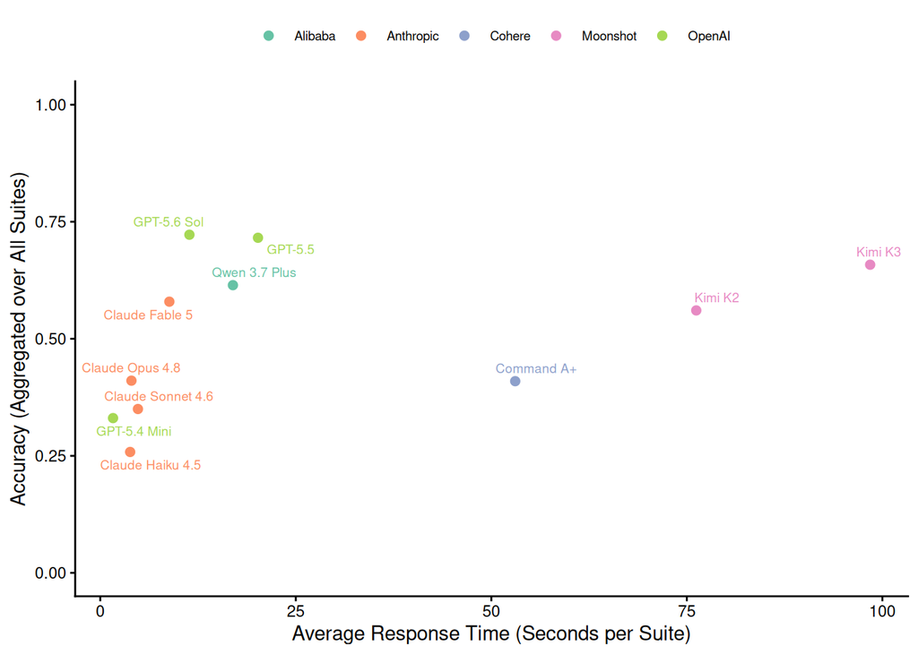

Figure 7: Relationship between accuracy and response time averaged over all suites for every model in our study, represented as points. Points are colour-coded according to their model providers. DeepSeek V4 Flash, DeepSeek V4 Pro, and Command R+ were omitted from this plot, as they were only evaluated on text-based suites.

## 4.4 Output token efficiency

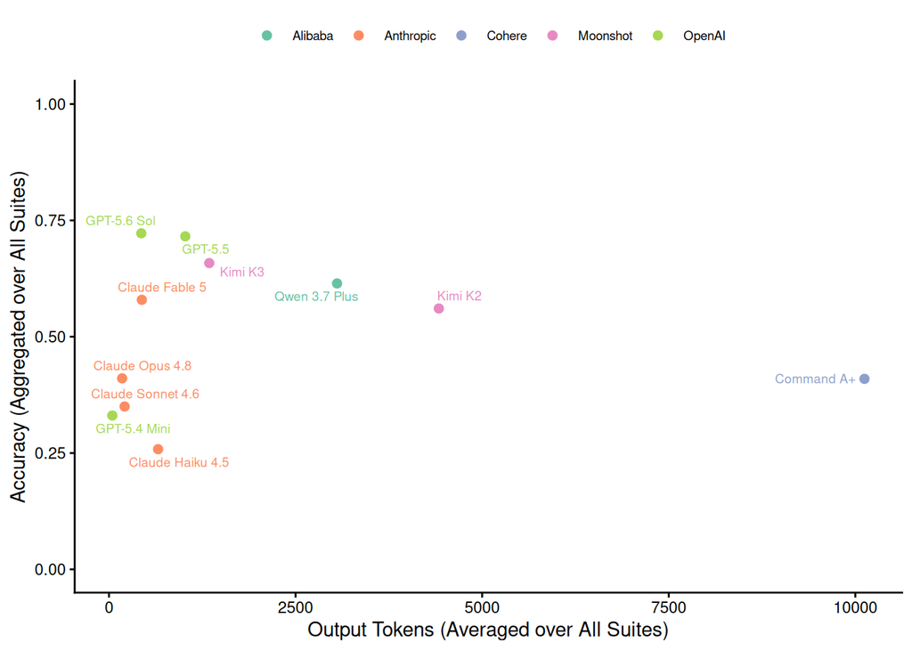

Figure 8: Relationship between accuracy and number of output tokens used averaged over all suites for every model in our study, represented as points. Points are colour-coded according to their model providers. DeepSeek V4 Flash, DeepSeek V4 Pro, and Command R+ were omitted from this plot, as they were only evaluated on text-based suites.

## 4.5 Accuracy over time

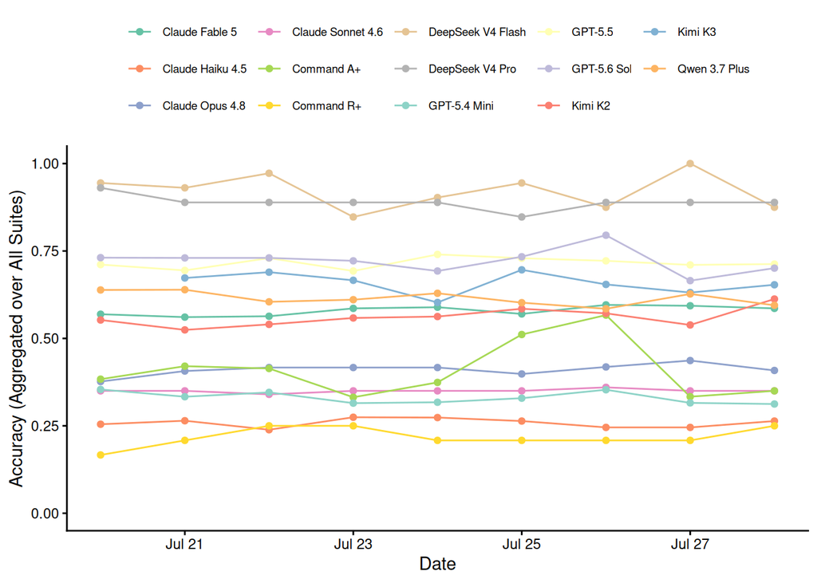

Figure 9: Time series of model performances from July 20, 2026 to July 28, 2026. Model performance is the average accuracy scored by the model across all suites. We note that DeepSeek V4 Flash, DeepSeek V4 Pro, and Command R+ displayed in this Figure were only evaluated on a subset of suites.

# 5 Discussion

## 5.1 Differentiating `GardenBench` from existing benchmarks

In conceptualizing `GardenBench`, we addressed two main shortcomings in previous methods of LLM benchmarking. First, `GardenBench` is publicly accessible, with conceivable results posted daily[^2]. This addresses concerns (for example, Guha et al. 2026; Koch et al. 2021) that LLM benchmarks tend to target audiences of niche scientific communities, with complex and highly specialized evaluations. Moreover, benchmarks are often conducted or published by model providers, for example, Anthropic (2026a)’s `BioMysteryBench`. Studies find that model providers tend to uniquely publish benchmarks on which their models performed well, choosing not to disclose less successful performances (Cheng et al. 2025; Baack et al. 2026; Mitchell et al. 2019). We believe that LLM evaluation mechanisms should be as broadly accessible as LLMs themselves, keeping pace with the widespread use of LLMs for general, everyday tasks by the vast public. By publishing all of our results to a live and public dashboard, we indiscriminately show LLM capabilities in a way that is meaningful and useful to broad LLM consumers.

## 5.2 Takeaways from model performance

Our benchmark construction process also revealed how prompt engineering may impact model performance. In developing testing suites, we observed that model performance improved significantly when models were asked to follow a specific prompt structure, for instance, in terms of capitalization and punctuation. Asking for one-word responses, comma-separated lists, or binary answers also allowed us to simplify our evaluation method while preserving reliability and depth of analysis.

Secondly, our results for model performance account for API run times and costs, exhibiting trade-offs associated with achieving accuracy.

Lastly, results from per suite performance clearly indicate the tasks where models struggle most as well as which specific models. Generally, models performed with low accuracy on suites like *Clothes* and *Books* which were both based on author-collected images, in the case of clothes images of a closet and in the case of books images of a bookshelf. In the case of the *Clothes* suite, we noticed the task at hand, counting the number of items folded in the closet may have been difficult for the models since some clothes were very thin, dark or looked very similar to each other and may not have been counted correctly. However, this is a task that can be easily performed by a human.

In the case of the *Books* suite, where models were tasked with naming the titles and authors of books in the bookshelf, they also performed with low accuracy. On many occasions, models were able to correctly identify the book title but failed to identify the author. It did not return an author name at all, and so it was given incorrect for that run.

Another suite containing author-collected images was the *Colours* suite. These were images of paintings mixed in a paint palette by one of the authors. Even though the images were also author-collected, models performed much better in terms of accuracy compared to the *Books* and *Clothes* suite. We believe that the fact that this prompt provided the model with some options to pick from made the models achieve such high accuracies compared to if they were given no options. For instance, a model would be asked to identify the three colors used in the palette, and given some options to pick from. This likely boosted model performance and we suspect that implementing this for the *Clothes* and *Books* suites would possibly boost accuracy as well.

Suites that involve internet-sourced images such as *Birds*, *Countries* and *Graphs*, performed better than suites involving author-collected images described above. Although it is unclear whether the quality of the images had an effect on the accuracies of the corresponding suites, it may have contributed to the lower performance on author-collected images compared to internet-sourced images. This may have also been due to the difficulty of the tasks themselves.

The most common error in the *Birds* suite was that most models correctly identified the Genus of the bird, but got the Species wrong. This resulted in a completely incorrect answer, since they didn’t consider partial correctness. In the *Countries* and *Graphs* the output from the model was entirely incorrect. For instance, in the *Countries* suite the main error was responding with the incorrect country. Conversely, there was variety of errors in the *Graphs* suite; in some cases the model was entirely incorrect by providing the wrong equation, in other cases the models attempted to match the shape of the image, but failed to plug in the numbers to actually check whether it matched, resulting in the incorrect function with a similar shape to the ground truth.

In terms of model specifics, Anthropic models returned reasoning frequently, despite being clearly instructed not to include pleasantries or additional text in their responses. On occasions where models returned additional text, even if the answer to the task was correct, answers were coded as incorrect. This is because our benchmark is not only checking that the models can perform the task correctly by providing the right answer, it is also checking whether the models are able to follow specific instructions by returning output that follows a structured schema (no additional text aside from the answer and specific answer format provided in the prompt itself).

## 5.3 Limitations and future directions

One limitation of our benchmark is that it involves text- and image-based prompting, even though 3 of our tested models (DeepSeek V4 Flash, DeepSeek V4 Pro, and Command-R+) were independently incapable of image processing. It is possible that the accuracy of these models may be overstated as they were evaluated on a reduced set of testing suites (4 suites instead of 11). Moreover, some testing suites varied in the number of tests included, which also could have influenced average accuracy representations.

In addition, our tests restricted models from web searching in order to evaluate the raw capabilities of LLMs. However, Internet information retrieval is an important feature of LLMs that is necessary for common general-use prompts. Therefore, future work could conduct similar general-purpose tests with extracting knowledge from the web as an option for LLMs. This would allow researchers to investigate whether model performance improves when supporting resources are used, and to what degree.

As LLM capabilities continue to progress, benchmarks should continuously expand evaluation to the newest features of LLMs, such as image and audio processing, as well as increasingly complex concepts and prompts. One way to do this is by having varying difficulty levels within one benchmark. Incorporating tasks with graduated complexity is another way to account for modest progress. In general, we encourage future benchmarks to continue evaluating LLM capabilities across general-use tasks that are relevant to broad communities, and that are relatively unaccounted for in existing benchmarks.

# 6 Conclusion

This paper introduced `GardenBench`, offering an innovative approach to measuring LLM capabilities across various general use cases. We join emerging calls to reduce the gatekeeping of LLM evaluation and help address this concern, primarily through the publication of https://gardenbench.ai/. The main objective of `GardenBench` is to make LLM evaluation publicly accessible, in a transparent and trustworthy manner. Granting broad access to such rankings allows us to understand the most effective ways to implement LLMs in our daily lives, as is already being done.

We also stress the importance of having benchmarks that can be run in a lightweight manner, such that they can be run frequently to capture model performance over time and adapted to new models effectively and immediately once they are released.

While it is important to monitor performance of models on domain-specific and complex tasks, it is equally important to develop benchmarks for general aptitude. The breadth of capabilities of ML models is increasingly as important as depth of knowledge, and performance on hyper-specific tasks. The field has moved from many specialized models to a few models that do everything. Researchers, businesses, and individuals now expect models that display general competence on new tasks given only a prompt or a few examples. For many parties deciding which model to use, the knowledge that a model is able to perform reasonably at several office tasks is more important than the knowledge that a model solves complex cybersecurity or mathematical problems.

# 7 Benchmark Test Suites and Data Overview

Below we provide more detail on the suites of `GardenBench` including a description of the tasks tested and an example of the prompts.

## 7.1 Birds

The Birds test suite evaluates the capacity of Large Language Models to process image data to perform species identification, where the model must identify the primary calling species using its scientific name. Performance across all experimental scenarios is automatically evaluated via exact-match string parsing against ground-truth files, tracking responses against `birds/01-ground_truth.txt` for the classification task and `birds/01-ground_truth.txt` for the species identification task.

**Example prompt:**

> This is an image of a specific species of bird. Respond with the scientific name of the species. Notes: Please respond in plaintext. Do not bold or italicize your answers. Place a space between the genus and the species. Do not include punctuation. RESPONSE STRUCTURE: [Genus] [species]

> Insert `birds/01-additional_file_01.png`

**Expected output:**

> Troglodytes hiemalis

## 7.2 Books

The Books test suite evaluates an LLM’s capability to parse complex visual data and extract structured information from images. The dataset consists of photographs of unique bookshelves of varying sizes and book quantities, captured directly by one of the authors with ground-truth labels established manually. Designed to imitate tasks performed in professional library settings, the suite features varying levels of difficulty. It tests the model’s ability to answer direct visual questions, ranging from simple tasks like identifying the first book on a shelf to listing out the entire bookshelf. It has also been provided a strict formatting structure, in order to enable the comparison of its result to a ground truth. These benchmarks require the model to parse the image accurately and combine visual inputs with external context to generate detailed lists of the volumes present.

For example, we have `books/01-additional_file_01.png` and we ask the model the following prompts as examples.

**Example prompt:**

> What is the first book on the left?

> Insert `books/01-additional_file_01.png`

> Please provide a list of the books.

**Expected output:**

> - Alammar, Jay, and Maarten Grootendorst, “Hands-On Large Language Models”
> - Galsworthy, John, “The Man of Property”
> - Galsworthy, John, “The Silver Spoon and Passers By”
> - Galsworthy, John, “The White Monkey and A Silent Wooing”
> - Galsworthy, John, “Swan Song”
> - Unknown

## 7.3 Ciphers

The Ciphers test suite evaluates an LLM’s capacity for algorithmic reasoning, character mapping adherence, and logical computation by requiring it to decode hidden words using fixed character-level transformation rules. The benchmark prevents models from relying on guessing or predictive patterns by making target outputs lack semantic or contextual cues. This could mean making a spelling error in the target word, and evaluating whether the LLM correctly computes it or instead incorrectly outputs the error-free word. In a baseline scenario, models are evaluated using a zero-shot prompt with an explicit output constraint, yielding a target string such as “BENCHMARK”. To test the limits of character-by-character logical execution, the suite introduces more complex extensions, including multi-step transformations such as f(x)=(ax+b)(mod26) and dynamic shifts based on character position. Performance is assessed via exact-match evaluation, where the model’s output is stripped of all whitespace and compared directly against the ground-truth target string.

**Example prompt:**

> Decode the hidden word using the given transformation rule. Alphabet mapping: A=0, B=1, …, Z=25. Rule: f(x)=25−x, where x represents the integer value of each letter.

> Encoded Word: YVMXSNZIP.

> Output Constraint: Return only the decoded word.

> Do not include any explanation, preamble, or punctuation”

> Insert `ciphers/01-additional_file_01.png`

**Expected output:**

> BENCHMARK

## 7.4 Clothes

The Clothes test suite benchmarks an LLM’s capacity for object detection, visual counting, and classification in a singular image. The dataset comprises ten photographs of a single closet, capturing changes across instances, such as the removal or rearrangement of specific items. All images were captured by one of the authors and are utilized for the benchmark with their consent. This design evaluates the model’s image recognition counting accuracy. Evaluation is conducted using zero-shot prompting strategies.

**Example prompt 1:**

> Task: Count the total number of items visible in the closet.

> Constraints:
> 1. Provide only the final count as a single integer.
> 2. Do not include any units, labels, introductory text, pleasantries, or explanations (e.g., return “14”, not “14 items”).

> Response Format: [Number]

> Insert `clothes/01-additional_file_01.png`

**Expected output:**

> 55

Model outputs are assessed via exact-match string parsing, comparing responses directly against the corresponding verification targets in closet/01_ground_truth.txt.

## 7.5 Colours

The Colours test suite introduces a benchmark that evaluates a model’s visual perception and reasoning. Rather than using standardized colour codes, the dataset consists of photographs of physical paint palettes containing mixed acrylic paints. This design assesses the model’s ability to handle artistic challenges and parse blends and textures of colours.

The model is first prompted with a palette image and asked to identify the kind. It is also prompted to list specific colours present. All images were captured by one of the authors and are utilized for the benchmark with their consent. Performance is evaluated through an exact-match. The model’s generated color list is compared directly against a ground-truth list of the exact color names, alphabetized for consistency.

**Example prompt 1:**

> What kind of paint was used in this palette? Please respond with one word.

> Insert `colours/01-additional_file_01.png`

**Expected output:**

> Acrylic

**Example prompt 2:**

> There are six distinct colours used to create the colour in the attached paint palette.

> The following is a list of the possible colours: Black, Brown, Dark Green, Forest Green, Light Blue, Prussian Blue, Turquoise, White, Yellow, Yellow Ochre.

> From this list, please return the six colours that were used on the palette in a comma-separated list, with capitalized colour names, and in alphabetical order.

> Insert `colours/12-additional_file_01.png`

**Expected output:**

> Dark Green, Forest Green, Prussian Blue, Turquoise, White, Yellow Ochre

## 7.6 Countries

The Countries test suite evaluates an LLM’s visual pattern recognition and geographic knowledge retrieval by challenging it to identify a specific country based on the outline of its geographic boundary. Inspired by the popular geography game [Worldle](https://worldle.teuteuf.fr), this benchmark forces models to process spatial contours and map those shapes to geographic data without relying on text labels, regional context, or surrounding borders. All images of country outlines were sourced from [Canva](https://www.canva.com/) under the Free Plan, and provided to the model as .png files. Evaluation is conducted across zero-shot and one-shot scenarios. In the zero-shot setting, the model is provided with a geographic file and a direct identification directive.

**Zero-shot example:**

> Insert `countries/01-additional_file_01.png`

> What country is this? Only return its name.

**Expected output:**

> Suriname

**One-shot scenario:**

> For example, this image: `countries/11-additional_file_01.png`

> Returns: Albania

> What country is this? Only return its name.

> Insert `countries/01-additional_file_01.png`

**Expected output:**

> Suriname

## 7.7 Graphs

The Graphs test suite measures geometric reasoning, visual data interpretation, and image-generation capabilities by prompting models to perform math operations on plots. Specifically, the benchmark requires the model to interpret the visual curve of a function and generate the corresponding graph of its first derivative, or conversely, to get the original function from a provided derivative graph. This task tests the model’s capacity to visually identify mathematical knowledge like inflection points, local extrema, and asymptotic behavior, and translate these into an accurate representation. The suite uses zero-shot prompting, where the configuration asks for the mathematical graph once provided the image input. Evaluation will then involve testing the LLM as a judge, and determine through a Yes/No if the images are identical.

**Example prompt:**

> Task: Analyze the provided graph of the function f(x) and output the equation of its derivative function, f’(x), as text.

> Here is the graph of f(x): `graphs_input_10.png`.

> Constraints:
> 1. The output must not be Latex, return simple text. That means, do not return ( f’(x) = 2x ), return f’(x)=2x.
> 2. Do not include any spaces. That means, do not return f’(x) = 2x, return f’(x)=2x.
> 3. Do not include any text explanations, markdown commentary, or pleasantries in your response.

> Output only the equation.

**Expected output:**

> f’(x)=2x

## 7.8 Puzzles

The Puzzles test suite benchmarks an LLM’s capacity for context-window rule adherence, logical reasoning, and multi-step deduction by evaluating its performance on Knights and Knaves logic puzzles (Smullyan 1981). In these scenarios, a set of characters are designated as either knights (who strictly speak the truth) or knaves (who strictly lie) and make self-referential statements about one another’s identities. These puzzles are deterministic and solvable via formal inference engines. We measure how reliably LLMs deduce pure logic compared to standard computation. The dataset comprises 10 structurally distinct puzzles featuring scaled complexities ranging from 3 to 6 characters and diverse statement types. The puzzles and corresponding solutions were programmatically generated and verified by adapting the open-source TruthQuest framework (Mondorf and Plank 2024).

**Example prompt:**

> In this puzzle, every character is either a knight or a knave: knights only tell the truth, and knaves only lie. Your objective is to determine the identity of every character based on what they say.

> You are met with 3 people, who say the following things:

> A: “B is a liar.”,

> B: “C is a liar.”,

> C: “A is a truth-teller and B is a truth-teller.”

> In your answer, you must clearly state the identity of each character by following the format:

> CONCLUSION:

> A: [Knight/Knave]

> B: [Knight/Knave]

> C: [Knight/Knave]

**Expected output:**

> CONCLUSION:

> A: Knave

> B: Knight

> C: Knave

## 7.9 Transit

**Example Prompt:**

> TASK: Here is a map of a city’s transit system. Respond with the list of stops between the following stops, separated by commas (including the start and end stops themselves):

> Insert `01-additional_file_01.png`

> START: Lawrence

> END: Rosedale

> NOTE: Decide on the path that includes the least amount of stops. Respond with only the list, nothing else.

**Expected output:**

> Lawrence, Eglinton, Davisville, St Clair, Summerhill, Rosedale

## 7.10 Ascii Haystack and Haystack

The Haystack Suite tests whether the model can identify a target string from within a large corpus of text. The main difference between Ascii Haystack and Haystack is that Ascii Haystack embeds the relevant information within random letters and symbols, whereas Haystack embeds random letters and symbols within coherent prose.

**Example Prompt for Ascii Haystack:**

> Embedded in this text is a fact about a person. Return this fact, and nothing else.

> The text is as follows:

> fivbifbkendjeriugbfuhvndkoerigrtiy4855836405ibe irhbein29448 tgriufbvirtub5837 54vifuberygb8475tg856f8erb v856fb8erbiruf beirubiurferuf857tgRohan’s middle name is Peter. 874fbrivbitgb 4587836e2938r058g8rt7vbubveirybg yfverb948bg8berbgirugbirugb59769eruvbivbivbivriuberb irgbtirberigbegbeirufbeirgbitygbdtghrt7vbubveirybgyfverb948 bg8rt7vbubveirybgy fverb948bg8.

**Expected output:**

> Rohan’s middle name is Peter.

**Example Prompt for Haystack:**

> Embedded in this text is a unique identifier, which is a UUID. Your task is to find and return this UUID.

> The text is as follows: JANE EYRE AN AUTOBIOGRAPHY by Charlotte Brontë ILLUSTRATED BY F. H. TOWNSEND London SERVICE & PATON 5 HENRIETTA STREET 1897 The Illustrations in this Volume are the copyright of SERVICE & PATON, London TO W. M. THACKERAY, ESQ., This Work IS RESPECTFULLY INSCRIBED BY THE AUTHOR PREFACE A preface to the first edition of “Jane Eyre” being unnecessary, I gave none: this second edition demands a few words both of acknowledgment and miscellaneous remark. My thanks are due in three quarters. To the Public, for the indulgent ear it has inclined to a plain tale with few pretensions. To the Press, for 1eb258ef-1bb6-4c9c-8cf8-125bbb0bb08c the fair field its honest suffrage has opened to an obscure aspirant. To my Publishers, for the aid their tact, their energy, their practical sense and frank liberality have afforded an unknown and unrecommended Author. The Press and the Public are but vague personifications for me, and I must thank them in vague terms; but my Publishers are definite: so are certain generous critics who have encouraged me as only large-hearted and high-minded men know how to encourage a struggling stranger; to them, i.e., to my

**Expected Output:**

> 1eb258ef-1bb6-4c9c-8cf8-125bbb0bb08c

## 7.11 Self Check

The Self Check test suite evaluates the model’s ability to answer questions about the environment in which it is operating, for instance, “What date is it today?”. This test encompasses a variety of text prompts and tests the model’s real time knowledge retrieval and system awareness.

**Example prompt:**

> What model are you? Return your API model slug only.

# 8 Additional tables and graphs

Table 3: Full table of accuracies by models and suites. Accuracies are averaged across time. We note that Deepseek V4 Flash, Deepseek V4 Pro, and Command R+ were only evaluated on text-based suites.

[output not shown]

Table 4: Full table of exact model API strings.

[output not shown]

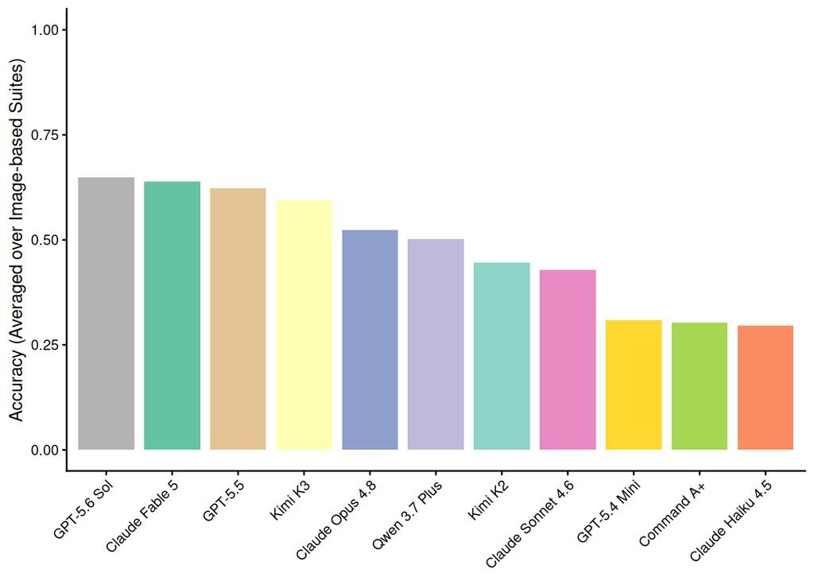

Figure 10: Performance by model, on only image-based suites.

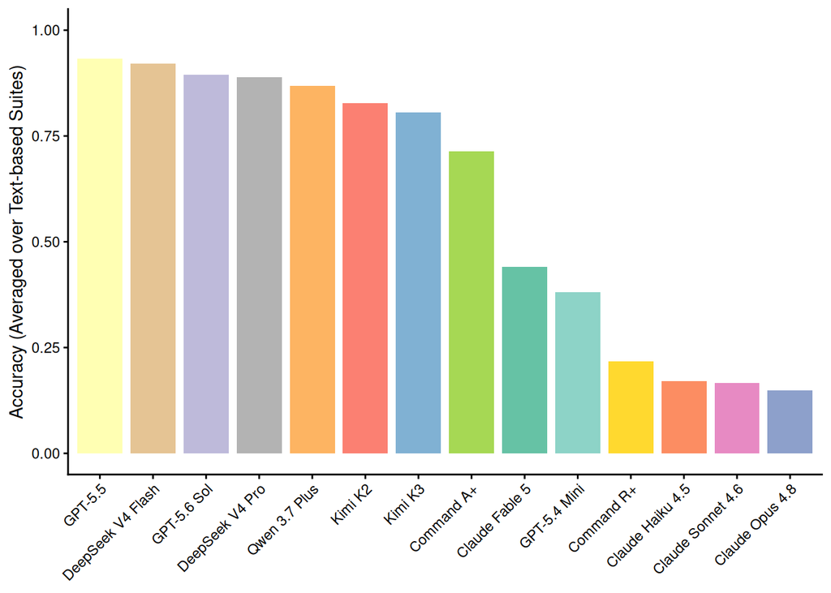

Figure 11: Performance by model, on only text-based suites.

## References

Ahn, Jihyun Janice, and Wenpeng Yin. 2025. *Prompt-Reverse Inconsistency: LLM Self-Inconsistency Beyond Generative Randomness and Prompt Paraphrasing*. https://arxiv.org/abs/2504.01282.

Akter, Syeda Nahida, Zichun Yu, Aashiq Muhamed, et al. 2023. *An in-Depth Look at Gemini’s Language Abilities*. https://arxiv.org/abs/2312.11444.

Anthropic. 2026a. *Evaluating Claude’s Bioinformatics Research Capabilities with BioMysteryBench*. https://www.anthropic.com/research/Evaluating-Claude-For-Bioinformatics-With-BioMysteryBench.

Anthropic. 2026b. *System Card: Claude Opus 5*. https://www-cdn.anthropic.com/b514064af1408018e64b1ad24e7d5e75850b4ffd/Claude%20Opus%205%20System%20Card.pdf.

Baack, Stefan, Maty Bohacek, and Christo Buschek. 2026. “Unsteady Metrics and Benchmarking Cultures of AI Model Builders.” (New York, NY, USA). https://doi.org/10.1145/3805689.3812240.

Bell, Robert M., Yehuda Koren, and Chris Volinsky. 2010. “All Together Now: A Perspective on the Netflix Prize.” *CHANCE*, no. 1: 24–29. https://doi.org/10.1080/09332480.2010.10739787.

Bommasani, Rishi, Drew A. Hudson, Ehsan Adeli, et al. 2022. *On the Opportunities and Risks of Foundation Models*. https://arxiv.org/abs/2108.07258.

Bommasani, Rishi, Kevin Klyman, Shayne Longpre, et al. 2023. *The Foundation Model Transparency Index*. https://arxiv.org/abs/2310.12941.

Brown, Tom B., Benjamin Mann, Nick Ryder, et al. 2020. “Language Models Are Few-Shot Learners.” *CoRR* abs/2005.14165. https://arxiv.org/abs/2005.14165.

Chen, Lingjiao, Matei Zaharia, and James Zou. 2024. “How Is ChatGPT’s Behavior Changing Over Time?” *Harvard Data Science Review* 6 (2). https://hdsr.mitpress.mit.edu/pub/y95zitmz/release/2.

Chen, Simin, Yiming Chen, Zexin Li, et al. 2025. “Benchmarking Large Language Models Under Data Contamination: A Survey from Static to Dynamic Evaluation.” In *Proceedings of the 2025 Conference on Empirical Methods in Natural Language Processing*, edited by Christos Christodoulopoulos, Tanmoy Chakraborty, Carolyn Rose, and Violet Peng. Association for Computational Linguistics. https://doi.org/10.18653/v1/2025.emnlp-main.511.

Cheng, Zerui, Stella Wohnig, Ruchika Gupta, et al. 2025. “Benchmarking is Broken – Don’t Let AI be its Own Judge.” *Advances in Neural Information Processing Systems* 38. https://proceedings.neurips.cc/paper_files/paper/2025/hash/693e00827fd44bdfca210801fe1e6439-Abstract-Position_Paper_Track.html.

Chiang, Wei-Lin, Lianmin Zheng, Ying Sheng, et al. 2024. *Chatbot Arena: An Open Platform for Evaluating LLMs by Human Preference*. https://arxiv.org/abs/2403.04132.

Cui, Jiaxin, and Rohan Alexander. 2026. *Same Prompt, Different Outcomes: Evaluating the Reproducibility of Data Analysis by LLMs*. https://arxiv.org/abs/2602.14349.

De Angelis, Inessa. 2026. “Using GitHub Actions for Computational Communication Research.” *SocArXiv*, ahead of print. https://doi.org/10.31235/osf.io/uqf6n_v1.

Dong, Yihong, Xue Jiang, Huanyu Liu, et al. 2024. *Generalization or Memorization: Data Contamination and Trustworthy Evaluation for Large Language Models*. https://arxiv.org/abs/2402.15938.

Epoch AI. 2026. *Data on AI Capabilities and Benchmarking*. Epoch AI; https://epoch.ai/benchmarks?view=graph&tab=eci.

Eriksson, Maria, Erasmo Purificato, Arman Noroozian, et al. 2025. *Can We Trust AI Benchmarks? An Interdisciplinary Review of Current Issues in AI Evaluation*. https://arxiv.org/abs/2502.06559.

Fabbri, Alexander R., Wojciech Kryściński, Bryan McCann, Caiming Xiong, Richard Socher, and Dragomir Radev. 2021. *SummEval: Re-Evaluating Summarization Evaluation*. https://arxiv.org/abs/2007.12626.

Fu, Yujuan, Ozlem Uzuner, Meliha Yetisgen, and Fei Xia. 2025. “Does Data Contamination Detection Work (Well) for LLMs? A Survey and Evaluation on Detection Assumptions.” In *Findings of the Association for Computational Linguistics: NAACL 2025*, edited by Luis Chiruzzo, Alan Ritter, and Lu Wang. Association for Computational Linguistics. https://doi.org/10.18653/v1/2025.findings-naacl.291.

Gemini Team. 2023. “Gemini: A Family of Highly Capable Multimodal Models.” *arXiv Preprint arXiv:2312.11805*.

Ggaliwango, Marvin, Hellen Nakayiza, Daudi Jjingo, and Joyce Nakatumba-Nabende. 2024. “Prompt Engineering in Large Language Models.” In *Data Intelligence and Cognitive Informatics*. https://doi.org/10.1007/978-981-99-7962-2_30.

Google DeepMind. 2026. *Gemini 3.5 Flash*. https://deepmind.google/models/model-cards/gemini-3-5-flash/.

Guha, Neel, Andy K. Zhang, Christine Tsang, Christopher D. Manning, Julian Nyarko, and Daniel E. Ho. 2026. “There is no free benchmark: An institutional view of legal AI benchmarking.” *Proceedings of the National Academy of Sciences of the United States of America*, no. 30. https://doi.org/10.1073/pnas.2509757122.

Gundlach, Hans, Jayson Lynch, Matthias Mertens, and Neil Thompson. 2026. *The Price of Progress: Price Performance and the Future of AI*. https://arxiv.org/abs/2511.23455.

Hendrycks, Dan, Collin Burns, Steven Basart, et al. 2021. *Measuring Massive Multitask Language Understanding*. https://arxiv.org/abs/2009.03300.

Hodak, Miro, David Ellison, Chris Van Buren, Xiaotong Jiang, and Ajay Dholakia. 2024. “Benchmarking Large Language Models: Opportunities and Challenges.” In *Performance Evaluation and Benchmarking*, edited by Raghunath Nambiar and Meikel Poess, vol. 14247. Lecture Notes in Computer Science. Springer. https://doi.org/10.1007/978-3-031-68031-1_6.

Hutchinson, Ben, Negar Rostamzadeh, Christina Greer, Katherine Heller, and Vinodkumar Prabhakaran. 2022. “Evaluation Gaps in Machine Learning Practice.” *Proceedings of the 2022 ACM Conference on Fairness, Accountability, and Transparency* (New York, NY, USA), FAccT ’22, 1859–76. https://doi.org/10.1145/3531146.3533233.

Jimenez, Carlos E., John Yang, Alexander Wettig, et al. 2024. *SWE-Bench: Can Language Models Resolve Real-World GitHub Issues?* https://arxiv.org/abs/2310.06770.

Kapoor, Sayash, Benedikt Stroebl, Peter Kirgis, et al. 2025. *Holistic Agent Leaderboard: The Missing Infrastructure for AI Agent Evaluation*. https://arxiv.org/abs/2510.11977.

Khairnar, Sushil. 2025. “A Survey of Temporal Drift in Large Language Models.” *TechRxiv* 2025 (1030). https://doi.org/10.36227/techrxiv.176184838.81737563/v1.

Koch, Bernard, Emily Denton, Alex Hanna, and Jacob G. Foster. 2021. “Reduced, Reused and Recycled: The Life of a Dataset in Machine Learning Research.” *Proceedings of the Neural Information Processing Systems Track on Datasets and Benchmarks (NeurIPS)*. https://arxiv.org/abs/2112.01716.

Laurent, Jon M, Albert Bou, Michael Pieler, et al. 2026. *LABBench2: An Improved Benchmark for AI Systems Performing Biology Research*. https://arxiv.org/abs/2604.09554.

Lee, Seunghyun, and David Brumley. 2026. *ExploitBench: A Capability Ladder Benchmark for LLM Cybersecurity Agents*. May. https://arxiv.org/abs/2605.14153.

Li, Jeremy, and Andrew Ho. 2026. “GeneBench: Assessing AI Agents for Multi-Stage Inference Problems in Genomics and Quantitative Biology.” *bioRxiv*, ahead of print. https://doi.org/10.64898/2026.04.22.720113.

Li, Yucheng, Yunhao Guo, Frank Guerin, and Chenghua Lin. 2024. “An Open-Source Data Contamination Report for Large Language Models.” In *Findings of the Association for Computational Linguistics: EMNLP 2024*, edited by Yaser Al-Onaizan, Mohit Bansal, and Yun-Nung Chen. Association for Computational Linguistics. https://doi.org/10.18653/v1/2024.findings-emnlp.30.

Liang, Percy, Rishi Bommasani, Tony Lee, et al. 2023. “Holistic Evaluation of Language Models.” *Transactions on Machine Learning Research*. https://arxiv.org/abs/2211.09110.

Liu, Hongwei, Zilong Zheng, Yuxuan Qiao, et al. 2024. *MathBench: Evaluating the Theory and Application Proficiency of LLMs with a Hierarchical Mathematics Benchmark*. https://arxiv.org/abs/2405.12209.

Mehta, Sushant. 2025. “Beyond Accuracy: A Multi-Dimensional Framework for Evaluating Enterprise Agentic AI Systems.” *arXiv Preprint arXiv:2511.14136*.

Merrill, Mike A., Alexander G. Shaw, Nicholas Carlini, et al. 2026. *Terminal-Bench: Benchmarking Agents on Hard, Realistic Tasks in Command Line Interfaces*. https://arxiv.org/abs/2601.11868.

Mialon, Grégoire, Clémentine Fourrier, Craig Swift, Thomas Wolf, Yann LeCun, and Thomas Scialom. 2023. *GAIA: A Benchmark for General AI Assistants*. https://arxiv.org/abs/2311.12983.

Mitchell, Margaret, Simone Wu, Andrew Zaldivar, et al. 2019. “Model Cards for Model Reporting.” (New York, NY, USA). https://doi.org/10.1145/3287560.3287596.

Mondorf, Philipp, and Barbara Plank. 2024. “Liar, Liar, Logical Mire: A Benchmark for Suppositional Reasoning in Large Language Models.” In *Proceedings of the 2024 Conference on Empirical Methods in Natural Language Processing*, edited by Yaser Al-Onaizan, Mohit Bansal, and Yun-Nung Chen. Association for Computational Linguistics. https://aclanthology.org/2024.emnlp-main.404.

Narayanan, Arvind. 2026. *What Will Be Left for Us to Work on?* Princeton University. https://www.cs.princeton.edu/~arvindn/talks/icml-2026-annotated-slides/#s28.

Ndzomga, Franck. 2026. “Efficient Benchmarking of AI Agents.” *arXiv Preprint arXiv:2603.23749*.

OpenAI. 2026a. *GPT-5.5 System Card*. https://deploymentsafety.openai.com/gpt-5-5.

OpenAI. 2026b. *Openai-Python: The Official Python Library for the OpenAI API*. Version 2.36.0. https://pypi.org/project/openai/.

Patwardhan, Aditya, Vivek Vaidya, and Ashish Kundu. 2025. *Automated Consistency Analysis of LLMs*. https://arxiv.org/abs/2502.07036.

Phan, Long and, Alice Gatti, Nathaniel Li, et al. 2026. “A Benchmark of Expert-Level Academic Questions to Assess AI Capabilities.” *Nature* 649 (8099): 1139–46. https://doi.org/10.1038/s41586-025-09962-4.

Pinhanez, Claudio, Paulo Cavalin, Cassia Sanctos, Marcelo Grave, and Yago Primerano. 2025. *The Non-Determinism of Small LLMs: Evidence of Low Answer Consistency in Repetition Trials of Standard Multiple-Choice Benchmarks*. https://arxiv.org/abs/2509.09705.

Polo, Felipe Maia, Lucas Weber, Leshem Choshen, Yuekai Sun, Gongjun Xu, and Mikhail Yurochkin. 2024. “tinyBenchmarks: evaluating LLMs with fewer examples.” In *Proceedings of the 41st International Conference on Machine Learning*, edited by Ruslan Salakhutdinov, Zico Kolter, Katherine Heller, et al., vol. 235. Proceedings of Machine Learning Research. PMLR. https://proceedings.mlr.press/v235/maia-polo24a.html.

Rabanser, Stephan, Sayash Kapoor, Peter Kirgis, Kangheng Liu, Saiteja Utpala, and Arvind Narayanan. 2026. *Towards a Science of AI Agent Reliability*. https://arxiv.org/abs/2602.16666.

Raji, Inioluwa Deborah, Emily M. Bender, Amandalynne Paullada, Emily Denton, and Alex Hanna. 2021. *AI and the Everything in the Whole Wide World Benchmark*. https://arxiv.org/abs/2111.15366.

Rein, David, Betty Li Hou, Asa Cooper Stickland, et al. 2023. *GPQA: A Graduate-Level Google-Proof q&a Benchmark*. https://arxiv.org/abs/2311.12022.

Reuel, Anka, Amelia Hardy, Chandler Smith, Max Lamparth, Malcolm Hardy, and Mykel J. Kochenderfer. 2024. *BetterBench: Assessing AI Benchmarks, Uncovering Issues, and Establishing Best Practices*. https://arxiv.org/abs/2411.12990.

Russakovsky, Olga, Jia Deng, Hao Su, et al. 2015. “ImageNet Large Scale Visual Recognition Challenge.” *International Journal of Computer Vision*, 211–52. https://doi.org/10.1007/s11263-015-0816-y.

Sahoo, Pranab, Ayush Kumar Singh, Sriparna Saha, Vinija Jain, Samrat Mondal, and Aman Chadha. 2025. *A Systematic Survey of Prompt Engineering in Large Language Models: Techniques and Applications*. https://arxiv.org/abs/2402.07927.

Smullyan, Raymond M. 1981. “What Is the Name of This Book? The Riddle of Dracula and Other Logical Puzzles.” *Critica* 13 (38): 126–30.

Song, Xiaoshuai, Muxi Diao, Guanting Dong, et al. 2025. *CS-Bench: A Comprehensive Benchmark for Large Language Models Towards Computer Science Mastery*. https://arxiv.org/abs/2406.08587.

Wan, Alexander, Kevin Klyman, Sayash Kapoor, et al. 2025. *The 2025 Foundation Model Transparency Index*. Stanford Center for Research on Foundation Models (CRFM); https://crfm.stanford.edu/fmti/December-2025/paper.pdf.

Wang, Chao, Neo Wu, Lin Ning, et al. 2024. *UserSumBench: A Benchmark Framework for Evaluating User Summarization Approaches*. https://arxiv.org/abs/2408.16966.

Wang, Zhun, Nico Schiller, Hongwei Li, et al. 2026. *ExploitGym: Can AI Agents Turn Security Vulnerabilities into Real Attacks?* https://arxiv.org/abs/2605.11086.

Wu, Xuansheng, Wenlin Yao, Jianshu Chen, et al. 2024. “From Language Modeling to Instruction Following: Understanding the Behavior Shift in LLMs After Instruction Tuning.” In *Proceedings of the 2024 Conference of the North American Chapter of the Association for Computational Linguistics: Human Language Technologies (Volume 1: Long Papers)*, edited by Kevin Duh, Helena Gomez, and Steven Bethard. Association for Computational Linguistics. https://doi.org/10.18653/v1/2024.naacl-long.130.

Xu, Cheng, Shuhao Guan, Derek Greene, and M-Tahar Kechadi. 2024. *Benchmark Data Contamination of Large Language Models: A Survey*. https://arxiv.org/abs/2406.04244.

Xuan, Weihao, Rui Yang, Heli Qi, et al. 2025. *MMLU-ProX: A Multilingual Benchmark for Advanced Large Language Model Evaluation*. https://arxiv.org/abs/2503.10497.

Zhou, Jeffrey, Tianjian Lu, Swaroop Mishra, et al. 2023. *Instruction-Following Evaluation for Large Language Models*. https://arxiv.org/abs/2311.07911.

Zhu, Yuxuan, Antony Kellermann, Dylan Bowman, et al. 2025. *CVE-Bench: A Benchmark for AI Agents’ Ability to Exploit Real-World Web Application Vulnerabilities*. https://arxiv.org/abs/2503.17332.

## Footnotes

[^1]: Many large providers offer specialized models for audio-based tasks such as speech-to-text processing (e.g. OpenAI’s Whisper).
[^2]: https://gardenbench.ai/